# Table of Content

- Problem: Using pipeline for KNN
- Problem: Using VDM with KNN

```python
import pandas as pd
import numpy as np
from sklearn.preprocessing import MinMaxScaler
from sklearn.pipeline import Pipeline
from sklearn.compose import make_column_selector as selector
from sklearn.compose import ColumnTransformer
from sklearn.neighbors import KNeighborsClassifier
from sklearn.metrics import accuracy_score

import plotly.graph_objects as go

from sklearn import set_config #To display pipeline
set_config(display="diagram")
```

# Problem: Using pipeline for KNN

In this problem you apply built-in KNN package to the healthcare data to predict adherent class (pdc-80-flag). Use of pipeline is recommended. Predict the pdc-80-flag using the following features ”pre-rx- cost”,”numofgen”,”numofbrand”,”generic-cost”,”adjust-total-30d”, and ”num- er”. Determine the accuracy rate for test set for k = 75 to 105 with a step size of 2 and report it in a table. Use linear normalization method to normalize the input features and Euclidean distance for distance measure. Note that you must use the training parameters for normalization of test points

### Import Data

```python
train_data = pd.read_csv('healthcareTrain.csv')
test_data = pd.read_csv('healthcareTest.csv')
print(train_data.shape, test_data.shape)
#train_data.info(verbose = True)
X_train = train_data[[ 'pre_rx_cost','numofgen','numofbrand',\
                     'generic_cost','adjust_total_30d', 'num_er']]
X_train.info(verbose = True)
y_train.info(verbose = True)
# The categorical data type is useful when you have a string variable consisting of only a few different values.
# Converting such a string variable to a categorical variable will save some memory
y_train = train_data['pdc_80_flag'].astype('category')
X_test = test_data[[ 'pre_rx_cost','numofgen','numofbrand',\
                    'generic_cost','adjust_total_30d', 'num_er']]
y_test = test_data['pdc_80_flag'].astype('category')
```

[output not shown]

```python
noncatg_pipeline = Pipeline(
    steps = [
        ("normalize", MinMaxScaler())
    ]
)
noncatg_pipeline
```

```
Pipeline(steps=[('normalize', MinMaxScaler())])
```

```python
columns_preprocessor = ColumnTransformer(
    transformers = [
        ('noncatg_transformer', noncatg_pipeline,\
         selector(dtype_exclude = ["object","category"])),
    ],
    remainder='passthrough'
    )
columns_preprocessor
```

```
ColumnTransformer(remainder='passthrough',
                  transformers=[('noncatg_transformer',
                                 Pipeline(steps=[('normalize',
                                                  MinMaxScaler())]),
                                 <sklearn.compose._column_transformer.make_column_selector object at 0x2a90d72e0>)])
```

```python
knn_model = Pipeline(
    steps = [
        ('preprocessor', columns_preprocessor),
        ( 'KNN', KNeighborsClassifier()), #Default value for n_neighbors is k = 5.
    ]
)
knn_model
```

```
Pipeline(steps=[('preprocessor',
                 ColumnTransformer(remainder='passthrough',
                                   transformers=[('noncatg_transformer',
                                                  Pipeline(steps=[('normalize',
                                                                   MinMaxScaler())]),
                                                  <sklearn.compose._column_transformer.make_column_selector object at 0x2a90d72e0>)])),
                ('KNN', KNeighborsClassifier())])
```

```python
#Toy example to see how fit, predict, and transform work.
import warnings
warnings.simplefilter(action='ignore', category=FutureWarning)
knn_model.fit(X_train, y_train)
# print(knn_model.predict(X_test.head(1)))
# print(knn_model[-1].classes_)

# print(knn_model[-2].transformers_,'\n')
# print(knn_model[-2].n_features_in_,'\n')
# print(knn_model[-2].feature_names_in_)
knn_model[-2].transform(X_test.head(1))
```

```
array([[0.06000999, 0.03030303, 0.36111111, 0.00530158, 0.11514495,
        0.        ]])
```

```python
def knn_model(k, X_train, y_train, X_test, y_test):
    model = Pipeline(
        steps = [
            ('preprocessor', columns_preprocessor),
            ( 'KNN', KNeighborsClassifier(n_neighbors = k)),
        ]
    )
    model.fit(X_train, y_train)
    y_test_pred = model.predict(X_test)
    accuracy = accuracy_score(y_test, y_test_pred)
    return(accuracy)
```

### Create the Model

Plot the accuracy rate vs. K. Which value of K gives you the best accuracy rate?

```python
acc_df = pd.DataFrame(columns = ['K', 'Accuracy'])
for k in range(75,106,2):
    acc = knn_model(k, X_train, y_train, X_test, y_test)
    acc_df = pd.concat([acc_df, pd.DataFrame([[k,acc]],columns = ["K","Accuracy"])])
fig = go.Figure()
fig.add_trace(go.Scatter(x = acc_df['K'], y = acc_df['Accuracy']))
fig.update_layout(xaxis_title = 'Number of Neighbors', yaxis_title = 'Accuracy')
fig.show()
# K = 103 gives the highest accuracy
```

[interactive chart not shown]

# Problem: Using VDM with KNN

```python
adTrain = pd.read_csv("healthcareTrain.csv")
adTest = pd.read_csv("healthcareTest.csv")
```

### Part 1: Find all the relevant conditional probabilities for finding VDM for symbolic variable region and report your results in a table

```python
#Create a crosstab for region vs pdc_flag
regionTable = pd.crosstab(adTrain['regionN'], adTrain['pdc_80_flag'])
regionTable.index = ["Northeast","Midwest","South","West"]
regionTable.columns = ["pdc_flag_0", "pdc_flag_1"]
regionTable
```

|  | pdc_flag_0 | pdc_flag_1 |
| --- | --- | --- |
| Northeast | 55 | 56 |
| Midwest | 228 | 173 |
| South | 500 | 274 |
| West | 53 | 39 |

```python
# Find all the relevant conditional probabilities for finding VDM for symbolic variable region
# e.g P(pdc_flag_0|region = NE)
# Therefore, we need to find the sum in each row and then divide each cell by that value
regionSum = regionTable.sum(axis = 1)
print(regionSum)
```

```
Northeast    111
Midwest      401
South        774
West          92
dtype: int64
```

```python
prob = regionTable.divide(regionSum, axis = 0)
prob
```

|  | pdc_flag_0 | pdc_flag_1 |
| --- | --- | --- |
| Northeast | 0.495495 | 0.504505 |
| Midwest | 0.568579 | 0.431421 |
| South | 0.645995 | 0.354005 |
| West | 0.576087 | 0.423913 |

### Part 2: Use results in part 1 to find the distance between symbolic feature values Northeast, Midwest, South, and West using VDM equation. Report the distances in a table.

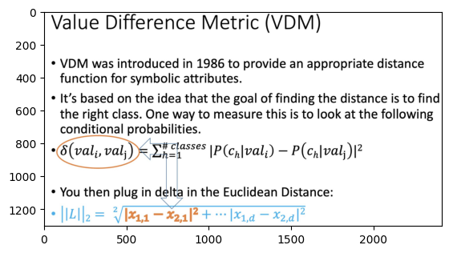

```python
from matplotlib import pyplot as plt

# Load the image
img = plt.imread('vdmSlide.jpg')

# Display the image
plt.imshow(img)
plt.show()
```

```python
# Use the vdm expression. e.g. delta(NE, MW) =[p(0|NE)-p(0|MW)]^2 + [p(1|NE)-p(1|MW)]^2
# This means we have to take the difference between the corresponding cells of those 2 rows.

from scipy.spatial import distance_matrix
delta = pd.DataFrame(distance_matrix(prob.values, prob.values)**2, index=prob.index, columns=prob.index)
delta
```

|  | Northeast | Midwest | South | West |
| --- | --- | --- | --- | --- |
| Northeast | 0.000000 | 0.010682 | 0.045300 | 0.012990 |
| Midwest | 0.010682 | 0.000000 | 0.011987 | 0.000113 |
| South | 0.045300 | 0.011987 | 0.000000 | 0.009774 |
| West | 0.012990 | 0.000113 | 0.009774 | 0.000000 |

```python
from sklearn.preprocessing import MinMaxScaler
contTitle = ["adjust_total_30d", "generic_cost","pre_rx_cost","numofgen","num_er","numofbrand"]
scaler = MinMaxScaler()
scaler.fit(adTrain[contTitle])
contTrain = pd.DataFrame(scaler.transform(adTrain[contTitle]), columns=contTitle)
contTest = pd.DataFrame(scaler.transform(adTest[contTitle]), columns=contTitle)
```

```python
# myDist is [train size] * [test size] => 1378 * 344
# col 1 (1378x1) is the distance between the first testPoint and all 1378 points in training
# col 2 (1378x1) is the distance between the second testPoint and all 1378 points in training, and so on.
myDist = distance_matrix(contTrain, contTest)
```

```python
# Note that myDist needs to be squared based on the formula
totalDis = np.sqrt(myDist**2 + delta.iloc[adTrain['regionN']-1, adTest['regionN']-1])
inx= pd.DataFrame(np.argsort(totalDis, axis=0))
print(inx.shape)
```

```
(1378, 344)
```

[output not shown]

```python
predictions = []
for K in range(75, 106, 2):
    df = inx.iloc[:K, :].apply(lambda x: np.array(adTrain['pdc_80_flag'])[x])
    predictions.append(np.array(df.apply(lambda x: 1 if x.sum()> (K/2) else 0)))
predMatrix = pd.DataFrame(predictions)
predMatrix
```

|  | 0 | 1 | 2 | 3 | 4 | 5 | 6 | 7 | 8 | 9 | ... | 334 | 335 | 336 | 337 | 338 | 339 | 340 | 341 | 342 | 343 |
| --- | --- | --- | --- | --- | --- | --- | --- | --- | --- | --- | --- | --- | --- | --- | --- | --- | --- | --- | --- | --- | --- |
| 0 | 0 | 0 | 0 | 0 | 0 | 0 | 0 | 0 | 1 | 1 | ... | 0 | 1 | 0 | 1 | 1 | 0 | 0 | 1 | 0 | 0 |
| 1 | 0 | 0 | 0 | 0 | 0 | 0 | 0 | 0 | 1 | 1 | ... | 0 | 1 | 0 | 1 | 1 | 0 | 0 | 1 | 0 | 0 |
| 2 | 0 | 0 | 0 | 0 | 0 | 0 | 0 | 0 | 1 | 0 | ... | 0 | 1 | 0 | 1 | 1 | 0 | 0 | 1 | 0 | 0 |
| 3 | 0 | 0 | 0 | 0 | 0 | 0 | 0 | 0 | 1 | 0 | ... | 0 | 1 | 0 | 1 | 0 | 0 | 0 | 1 | 0 | 0 |
| 4 | 0 | 0 | 0 | 0 | 0 | 0 | 0 | 0 | 1 | 0 | ... | 0 | 1 | 0 | 1 | 1 | 0 | 0 | 1 | 0 | 0 |
| 5 | 0 | 0 | 0 | 0 | 0 | 0 | 0 | 0 | 1 | 1 | ... | 0 | 1 | 0 | 1 | 1 | 0 | 0 | 1 | 0 | 0 |
| 6 | 0 | 0 | 0 | 0 | 0 | 0 | 0 | 0 | 1 | 0 | ... | 0 | 1 | 0 | 1 | 0 | 0 | 0 | 1 | 0 | 0 |
| 7 | 0 | 0 | 0 | 0 | 0 | 0 | 0 | 0 | 1 | 0 | ... | 0 | 1 | 0 | 1 | 0 | 0 | 0 | 1 | 0 | 0 |
| 8 | 0 | 0 | 0 | 0 | 0 | 0 | 0 | 0 | 1 | 1 | ... | 0 | 1 | 0 | 1 | 0 | 0 | 0 | 1 | 0 | 0 |
| 9 | 0 | 0 | 0 | 0 | 0 | 0 | 0 | 0 | 1 | 1 | ... | 0 | 1 | 0 | 1 | 0 | 0 | 0 | 1 | 0 | 0 |
| 10 | 0 | 0 | 0 | 0 | 0 | 0 | 0 | 0 | 1 | 1 | ... | 0 | 1 | 0 | 1 | 0 | 0 | 0 | 1 | 0 | 0 |
| 11 | 0 | 0 | 0 | 0 | 0 | 0 | 0 | 0 | 1 | 1 | ... | 0 | 1 | 0 | 1 | 0 | 0 | 0 | 1 | 0 | 0 |
| 12 | 0 | 0 | 0 | 0 | 0 | 0 | 0 | 0 | 1 | 0 | ... | 0 | 1 | 0 | 1 | 0 | 0 | 0 | 1 | 0 | 0 |
| 13 | 0 | 0 | 0 | 0 | 0 | 0 | 0 | 0 | 1 | 0 | ... | 0 | 1 | 0 | 1 | 0 | 0 | 0 | 1 | 0 | 0 |
| 14 | 0 | 0 | 0 | 0 | 0 | 0 | 0 | 0 | 1 | 0 | ... | 0 | 1 | 0 | 1 | 0 | 0 | 0 | 1 | 0 | 0 |
| 15 | 0 | 0 | 0 | 0 | 0 | 0 | 0 | 0 | 1 | 0 | ... | 0 | 1 | 0 | 1 | 0 | 0 | 0 | 1 | 0 | 0 |

16 rows × 344 columns

```python
acc = predMatrix.apply(lambda x: x == adTest['pdc_80_flag'], axis=1).mean(axis=1)
acc_df = pd.DataFrame({'K': range(75, 106, 2),'Accuracy': acc})
acc_df
```

|  | K | Accuracy |
| --- | --- | --- |
| 0 | 75 | 0.659884 |
| 1 | 77 | 0.648256 |
| 2 | 79 | 0.648256 |
| 3 | 81 | 0.651163 |
| 4 | 83 | 0.648256 |
| 5 | 85 | 0.651163 |
| 6 | 87 | 0.633721 |
| 7 | 89 | 0.645349 |
| 8 | 91 | 0.645349 |
| 9 | 93 | 0.648256 |
| 10 | 95 | 0.639535 |
| 11 | 97 | 0.636628 |
| 12 | 99 | 0.633721 |
| 13 | 101 | 0.630814 |
| 14 | 103 | 0.642442 |
| 15 | 105 | 0.654070 |

### Part 4: Plot the accuracy rate vs. K. Which value of K gives you the best accuracy rate

```python
fig = go.Figure()
fig.add_trace(go.Scatter(x = acc_df['K'], y = acc_df['Accuracy']))
fig.update_layout(xaxis_title = 'Number of Neighbors', yaxis_title = 'Accuracy')
fig.show()
print('K = 75 has the highest level of accuracy')
```

[interactive chart not shown]

```
K = 75 has the highest level of accuracy
```

### Part 5: What did your best model predict for the 100th, 200th, and 300th test points?

```python
print(predMatrix.iloc[0,[99,199, 299]])
```

```
99     0
199    0
299    0
Name: 0, dtype: int64
```